# Automatic tools for improving packages

Maëlle Salmon (@ma_salmon)

RUG Barcelona, 13th of June 2017

# Introduction

# Who am I? (1/2)

- Data manager/statistician for CHAI project at ISGlobal.
- PhD in statistics.
- R user, developper, addict.
- R-Ladies BCN co-organizer.
- Co-editor at rOpenSci onboarding (more on that later!)

# Who am I? (2/2): Mowgli’s sister!

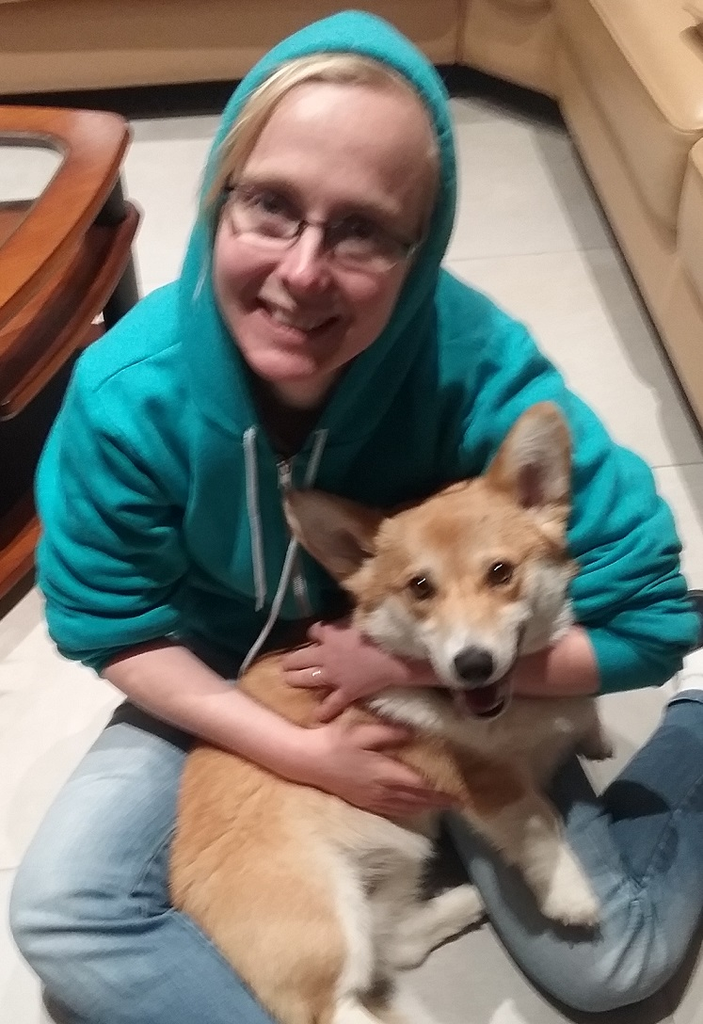

# What does improving the package mean?

- Coding style (against errors, and for future readers&contributors)
- Tests (such good safeguards!)
- Structure (follow the rules)
- Documentation (think of the users, including you in 3 months!)
- Not mentioned today: features, performance

# Functions for improving packages!

[figure not shown]

# Automatic tools?

- Automatic suggestions of improvements
- Not automatic corrections… Animo!

# Today’s talk

For each tool,

- Introduction
- Application to `fakepackage`. https://github.com/maelle/fakepackage

Questions any time chic@s!

# R CMD Check

# R CMD Check, what’s that?

- Necessary before any CRAN submission, useful anyway
- Package structure (bye bye, left-over files), missing documentation, dependencies.
- Runs tests, checks examples and vignettes.
- ERROR/WARNING/NOTE

# R CMD Check live

# Not time for it but…

- Continuous integration is great!

https://juliasilge.com/blog/beginners-guide-to-travis/

- Check out R-hub https://github.com/r-hub/rhub

# `lintr`, Static Code Analysis for R

# What is Jim Hester’s `lintr`?

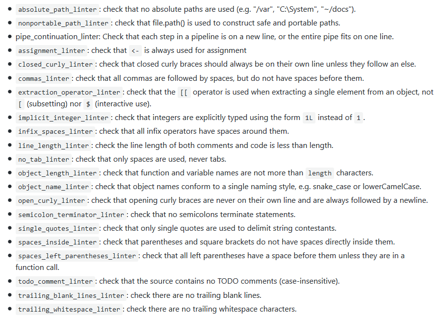

# Let’s use `lintr`!

# Bonus tip, `lintr` unit test

- the test

```r
if (requireNamespace("lintr", quietly = TRUE)) {
  context("lints")
  test_that("Package Style", {
    lintr::expect_lint_free()
  })
}
```

- .lintr at the root if non-default linters

```r
with_defaults(camel_case_linter = NULL, # you prefer camel case
              snake_case_linter, # so flag snake case
              line_length_linter(120)) # you love long lines
```

# `goodpractice`, Advice on R Package Building by Gabor Csardi

# `goodpractice` presentation

- https://github.com/MangoTheCat/goodpractice
- actually uses some `lintr` linters.
- tunable but I like the defaults.
- “Advice includes functions and syntax to avoid, package structure, code complexity, code formatting, etc.”

# `goodpractice` and `fakepackage`

# `devtools::spell_check()`

# `devtools::spell_check()`

- Function written by Jeroen Ooms.
- Let’s try it!
- Also good to know, `devtools::release()` when submitting a package to CRAN.

# `pkgdown`, Generate static html documentation for an R package

# `pkgdown`

- A package by Hadley Wickham.
- https://github.com/hadley/pkgdown
- Minimal effort from existing documentation to website!

# `pkgdown` for `fakepackage`

# `pkgdown` on `fakepackage`: customization

- Create a file at the root of the repo called `_pkgdown.yml`
- Styles, see https://bootswatch.com/
- Group functions & vignettes. Use `pkgdown::template_blabla` as starting point.

Example https://github.com/dirkschumacher/ompr/blob/master/_pkgdown.yml

# Conclusion

# Tools we’ve seen

- R CMD check
- `lintr`
- `devtools::spell_check()`
- `goodpractice::gp()`
- `pkgdown::build_site()`

# Tools we haven’t seen

- Continuous integration, cf [this post of Julia Silge’s](http://juliasilge.com/blog/Beginners-Guide-to-Travis/)
- Online code coverage services such as codecov.io
- Any other suggestion?

# Further resources

- Hadley Wickham’s book [“R Packages”](http://r-pkgs.had.co.nz/)
- Hadley Wickham’s [`strict` package](https://github.com/hadley/strict)
- rOpenSci’s CRAN Task View about package development https://github.com/ropensci/PackageDevelopment

# Small tip before even creating your package

Package name check via `available`. https://github.com/ropenscilabs/available

```r
available::available("dplyr")
available::available("chicken")
```

# Have your code&docs read by humans

- Peer-review at work or among friends
- [The R Journal](https://journal.r-project.org/), [Journal of Open Science Software](http://joss.theoj.org/about)
- [rOpenSci onboarding system!](https://github.com/ropensci/onboarding) Who wants to become a reviewer?

# Where to find me

- Github: maelle
- Twitter: ma_salmon

And you can also talk to me now!

Thanks for coming and listening!